# GroupC_HW4

# GAM

This question is about using gam for univariate smoothing, the advantages of penalized regression and weighting a smooth model fit. The mcycle data in the MASS package are a classic dataset in univariate smoothing, introduced in Silverman (1985). The data measure the acceleration of the rider’s head, against time, in a simulated motorcycle crash.

1. Plot the acceleration against time, and use gam to fit a univariate smooth to the data, selecting the smoothing parameter by GCV (k of 30 to 40 is plenty for this example). Plot the resulting smooth, with partial residuals, but without standard errors.
2. Use lm and poly to fit a polynomial to the data, with approximately the same degrees of freedom as was estimated by gam. Use termplot to plot the estimated polynomial and partial residuals. Note the substantially worse fit achieved by the polynomial, relative to the penalized regression spline fit.
3. It’s possible to overstate the importance of penalization in explaining the improvement of the penalized regression spline, relative to the polynomial. Use gam to refit an un-penalized thin plate regression spline to the data, with basis dimension the same as that used for the polynomial, and again produce a plot for comparison with the previous two results.
4. Redo part 3 using an un-penalized cubic regression spline. You should find a fairly clear ordering of the acceptability of the results for the four models tried - what is it?
5. Now plot the model residuals against time, and comment.
6. Fit a linear model including a b-spline using the function bs on times and select a suitable degree and the knots position. Compare this model with the previous ones and comment.

**Solution**

```r
library(MASS)
library(mgcv)
data(mcycle)

# If we don't do this mcycle is a closure
df <- as.data.frame(matrix(c(mcycle$accel, mcycle$time), ncol = 2))
names(df) <- c("accel", "time")
```

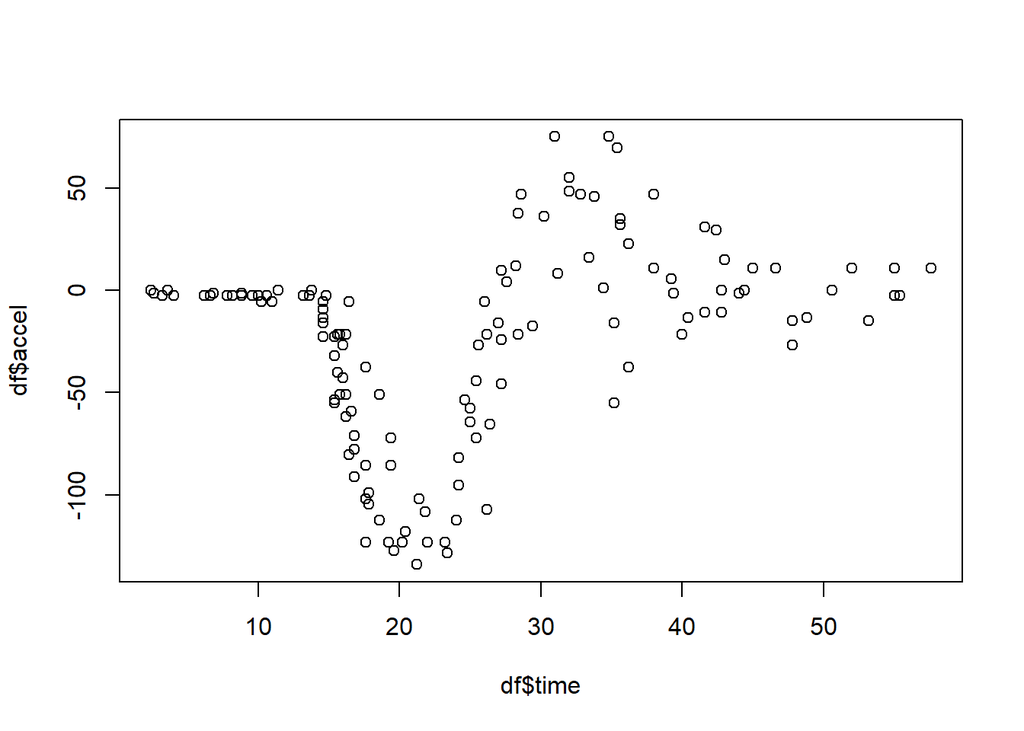

```r
plot(df$time, df$accel)
```

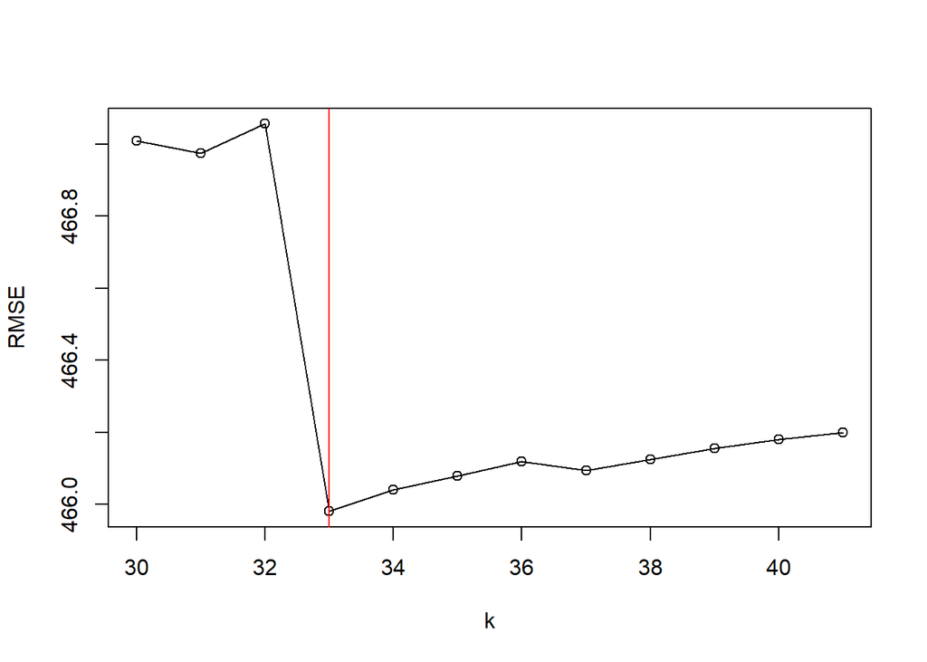

```r
RMSE <- rep(0, 12)

for (i in seq(30, 41)){
  gam_fit <- gam(accel ~ s(time, k = i), data = df)
  RMSE[i-29] <- mean(gam_fit$residuals^2)
}

plot(30:41, RMSE, type = "o", xlab = "k", ylab = "RMSE")
abline(v = 30 + which.min(RMSE) - 1, col = "red")
```

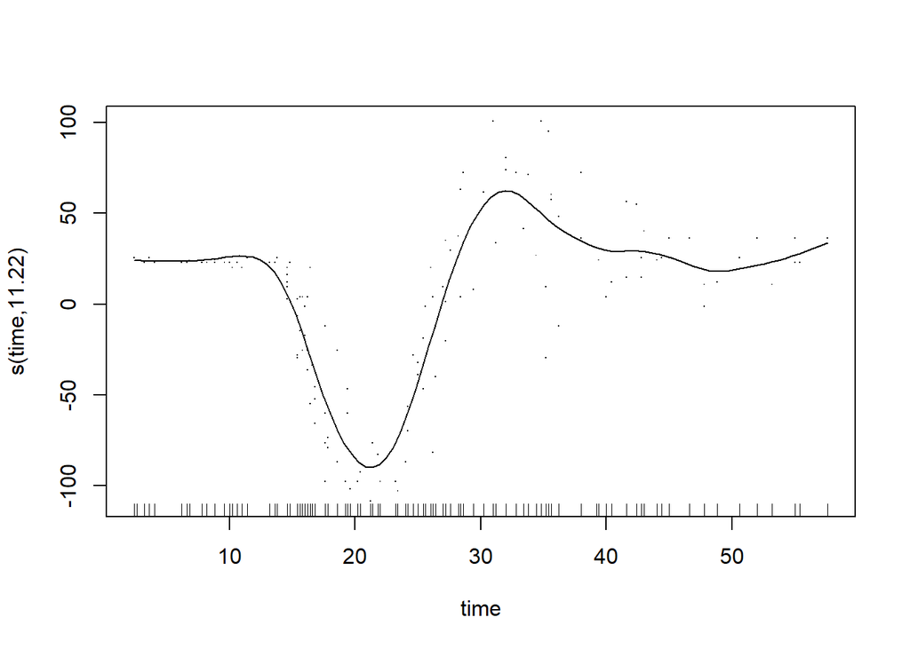

```r
fit_1 <- gam_fit <- gam(accel ~ s(time, k = 30+which.min(RMSE)-1), method = "GCV.Cp", data = df)
plot(fit_1, residuals = TRUE, se = FALSE)
```

```r
summary(fit_1)
```

```
##
## Family: gaussian
## Link function: identity
##
## Formula:
## accel ~ s(time, k = 30 + which.min(RMSE) - 1)
##
## Parametric coefficients:
##             Estimate Std. Error t value Pr(>|t|)
## (Intercept)  -25.546      1.964  -13.01   <2e-16 ***
## ---
## Signif. codes:  0 '***' 0.001 '**' 0.01 '*' 0.05 '.' 0.1 ' ' 1
##
## Approximate significance of smooth terms:
##           edf Ref.df    F p-value
## s(time) 11.22  13.91 33.2  <2e-16 ***
## ---
## Signif. codes:  0 '***' 0.001 '**' 0.01 '*' 0.05 '.' 0.1 ' ' 1
##
## R-sq.(adj) =   0.78   Deviance explained = 79.9%
## GCV = 565.02  Scale est. = 513.12    n = 133
```

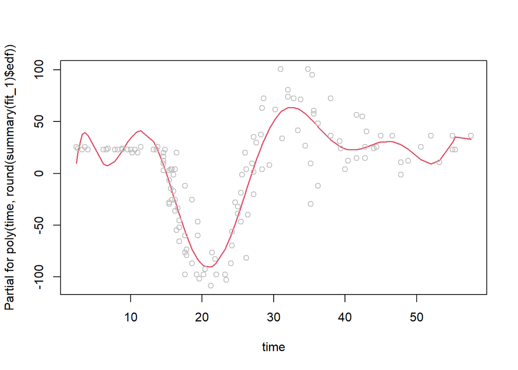

```r
fit_2 <- lm(accel ~ poly(time, round(summary(fit_1)$edf)), data = df)

termplot(fit_2, partial.resid = TRUE, se = FALSE)
```

```r
summary(fit_2)
```

```
##
## Call:
## lm(formula = accel ~ poly(time, round(summary(fit_1)$edf)), data = df)
##
## Residuals:
##     Min      1Q  Median      3Q     Max
## -81.824 -13.761   1.198  12.838  50.968
##
## Coefficients:
##                                         Estimate Std. Error t value Pr(>|t|)
## (Intercept)                              -25.546      2.042 -12.510  < 2e-16
## poly(time, round(summary(fit_1)$edf))1   164.557     23.550   6.987 1.64e-10
## poly(time, round(summary(fit_1)$edf))2   131.227     23.550   5.572 1.55e-07
## poly(time, round(summary(fit_1)$edf))3  -239.790     23.550 -10.182  < 2e-16
## poly(time, round(summary(fit_1)$edf))4    -6.738     23.550  -0.286 0.775288
## poly(time, round(summary(fit_1)$edf))5   245.799     23.550  10.437  < 2e-16
## poly(time, round(summary(fit_1)$edf))6   -83.906     23.550  -3.563 0.000526
## poly(time, round(summary(fit_1)$edf))7  -153.596     23.550  -6.522 1.69e-09
## poly(time, round(summary(fit_1)$edf))8   163.064     23.550   6.924 2.26e-10
## poly(time, round(summary(fit_1)$edf))9    31.879     23.550   1.354 0.178370
## poly(time, round(summary(fit_1)$edf))10 -141.518     23.550  -6.009 2.02e-08
## poly(time, round(summary(fit_1)$edf))11   24.240     23.550   1.029 0.305402
##
## (Intercept)                             ***
## poly(time, round(summary(fit_1)$edf))1  ***
## poly(time, round(summary(fit_1)$edf))2  ***
## poly(time, round(summary(fit_1)$edf))3  ***
## poly(time, round(summary(fit_1)$edf))4
## poly(time, round(summary(fit_1)$edf))5  ***
## poly(time, round(summary(fit_1)$edf))6  ***
## poly(time, round(summary(fit_1)$edf))7  ***
## poly(time, round(summary(fit_1)$edf))8  ***
## poly(time, round(summary(fit_1)$edf))9
## poly(time, round(summary(fit_1)$edf))10 ***
## poly(time, round(summary(fit_1)$edf))11
## ---
## Signif. codes:  0 '***' 0.001 '**' 0.01 '*' 0.05 '.' 0.1 ' ' 1
##
## Residual standard error: 23.55 on 121 degrees of freedom
## Multiple R-squared:  0.7823, Adjusted R-squared:  0.7625
## F-statistic: 39.52 on 11 and 121 DF,  p-value: < 2.2e-16
```

We can notice that the polynomial fit is much worse than the penalized regression spline fit. This is because it can’t manage to capture the linearity in the left part of the function.

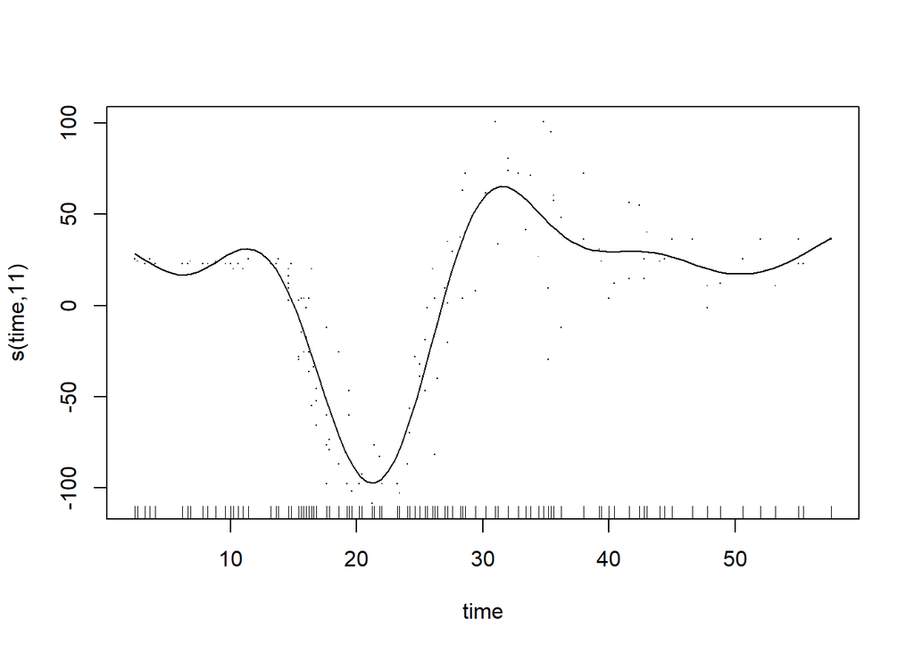

```r
fit_3 <- gam(accel ~ s(time, k = 12), method="GCV.Cp", sp=0, data = df)

plot(fit_3, residuals = TRUE, se = FALSE)
```

```r
summary(fit_3)
```

```
##
## Family: gaussian
## Link function: identity
##
## Formula:
## accel ~ s(time, k = 12)
##
## Parametric coefficients:
##             Estimate Std. Error t value Pr(>|t|)
## (Intercept)  -25.546      1.964     -13   <2e-16 ***
## ---
## Signif. codes:  0 '***' 0.001 '**' 0.01 '*' 0.05 '.' 0.1 ' ' 1
##
## Approximate significance of smooth terms:
##         edf Ref.df    F p-value
## s(time)  11     11 43.6  <2e-16 ***
## ---
## Signif. codes:  0 '***' 0.001 '**' 0.01 '*' 0.05 '.' 0.1 ' ' 1
##
## R-sq.(adj) =   0.78   Deviance explained = 79.9%
## GCV = 564.12  Scale est. = 513.22    n = 133
```

The fit is much better than the polynomial one and really similar to the penalized regression spline fit. Even if the penalization is not used, the fit results really smooth.

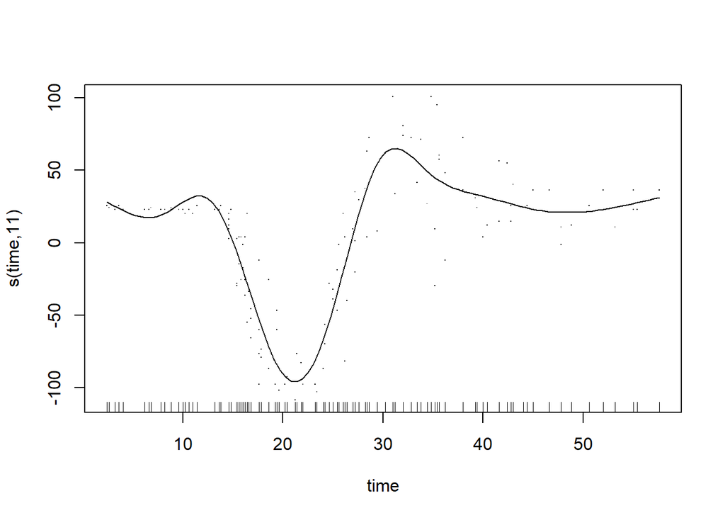

```r
## Is bs="cc" the cubic spline?
fit_4 <- gam(accel ~ s(time, k = 12, bs="cr"), method = "GCV.Cp", sp=0, data=df)
plot(fit_4, residuals = TRUE, se = FALSE)
```

```r
summary(fit_4)
```

```
##
## Family: gaussian
## Link function: identity
##
## Formula:
## accel ~ s(time, k = 12, bs = "cr")
##
## Parametric coefficients:
##             Estimate Std. Error t value Pr(>|t|)
## (Intercept)  -25.546      1.967  -12.99   <2e-16 ***
## ---
## Signif. codes:  0 '***' 0.001 '**' 0.01 '*' 0.05 '.' 0.1 ' ' 1
##
## Approximate significance of smooth terms:
##         edf Ref.df     F p-value
## s(time)  11     11 43.44  <2e-16 ***
## ---
## Signif. codes:  0 '***' 0.001 '**' 0.01 '*' 0.05 '.' 0.1 ' ' 1
##
## R-sq.(adj) =   0.78   Deviance explained = 79.8%
## GCV =  565.7  Scale est. = 514.66    n = 133
```

Even if the two fits are really similar, we have some differences on the right part of the function. The cubic spline fit is a little bit more smooth than the thin spline fit.

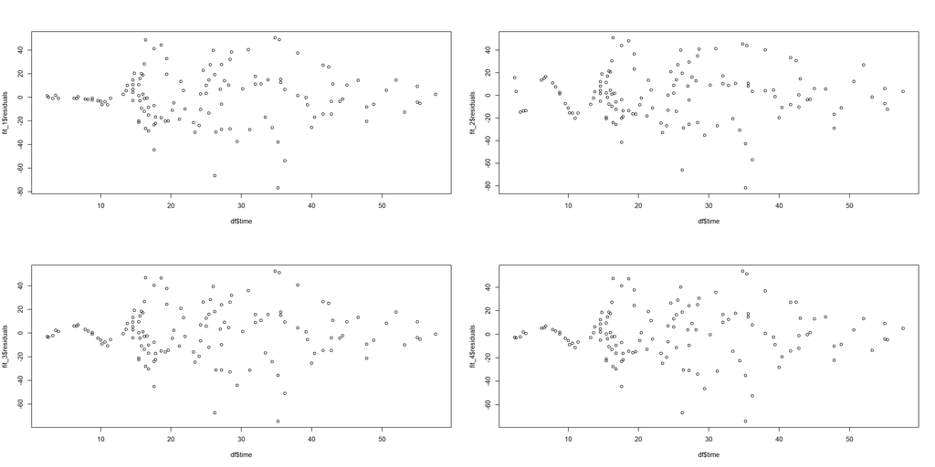

```r
par(mfrow=c(2,2))

plot(df$time, fit_1$residuals)
plot(df$time, fit_2$residuals)
plot(df$time, fit_3$residuals)
plot(df$time, fit_4$residuals)
```

We can notice that the residual plots looks all the same. They are all heteroskedastic because in the center we can notice more variance than in the left and right part of the function. Therefore in the left part we can notice some irregularities beside in the first fit, which looks more linear. From these plots we can notice that the first fit is the best one.

We select the knots for each decile of the time variable and we add a knot in the right part of the function to capture the linearity.

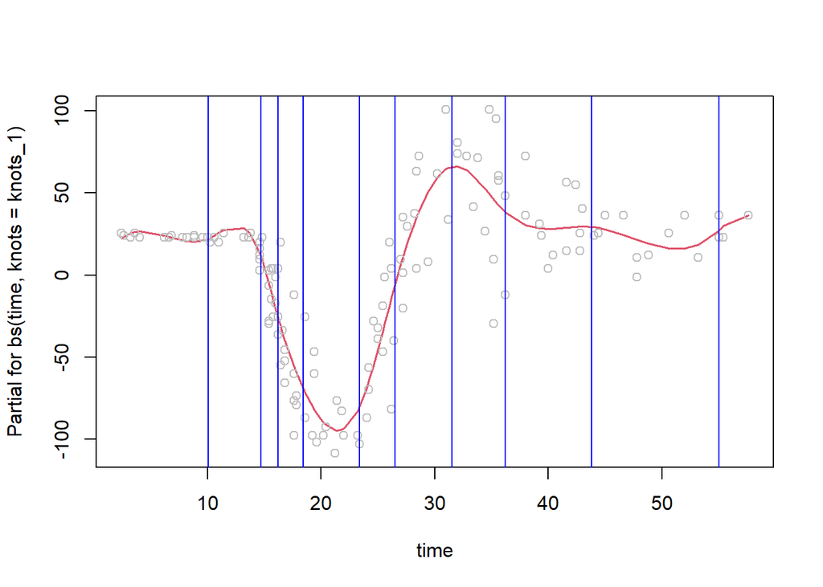

```r
knots_1 <- c(quantile(df$time, probs = seq(0.1, 0.9, 0.1)), 55)
fit_5 <- lm(accel ~ bs(time, knots=knots_1), data = df, )
termplot(fit_5,  partial.resid = TRUE, se = FALSE)
abline(v = knots_1, col = "blue")
```

The curve looks really similar to the first fit. We can notice that the fit is not really smooth in the right part of the function. This is because we have only one knot in the right part of the function. If we add more knots in the right part of the function we can notice that the fit is more smooth.

```r
df2 <- data.frame("model" = seq(1, 5),
                  "dev_explained" = c(summary(fit_1)$dev.expl, summary(fit_2)$r.squared, summary(fit_3)$dev.expl, summary(fit_4)$dev.expl, summary(fit_5)$r.squared),
                  "AIC" = c(AIC(fit_1), AIC(fit_2), AIC(fit_3), AIC(fit_4), AIC(fit_5)),
                  "BIC" = c(BIC(fit_1), BIC(fit_2), BIC(fit_3), BIC(fit_4), BIC(fit_5)))
```

```r
df2
```

```
##   model dev_explained      AIC      BIC
## 1     1     0.7989266 1221.044 1259.247
## 2     2     0.7822733 1231.192 1268.766
## 3     3     0.7985224 1220.876 1258.450
## 4     4     0.7979592 1221.247 1258.822
## 5     5     0.8029157 1221.944 1265.299
```

From the table we can notice that the last fit is the best one w.r.t. the explained deviance but the AIC and the BIC are higher. Paying a little of explained deviance we can have a better fit with a lower AIC and BIC with the third fit. This differences are not really big, so we can choose one of all the fits based on the requirements of the problem. The only really bad fit is the second one, which has a really low explained deviance and a really high AIC and BIC.